# Bayesian GLMM Part10

- stan_acf (auto-correlation function): plots the auto-correlation between successive MCMC sample lags for each parameter and each chain

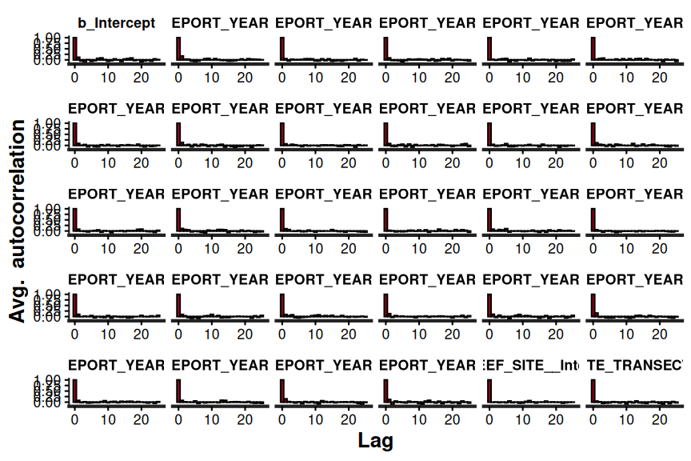

```r
ltmp_sub_brm1b$fit |>
    stan_ac(pars = pars)
```

There is no evidence of auto-correlation in the MCMC samples

- stan_rhat: Rhat is a **scale reduction factor** measure of convergence between the chains. The closer the values are to 1, the more the chains have converged. Values greater than 1.05 indicate a lack of convergence. There will be an Rhat value for each parameter estimated.

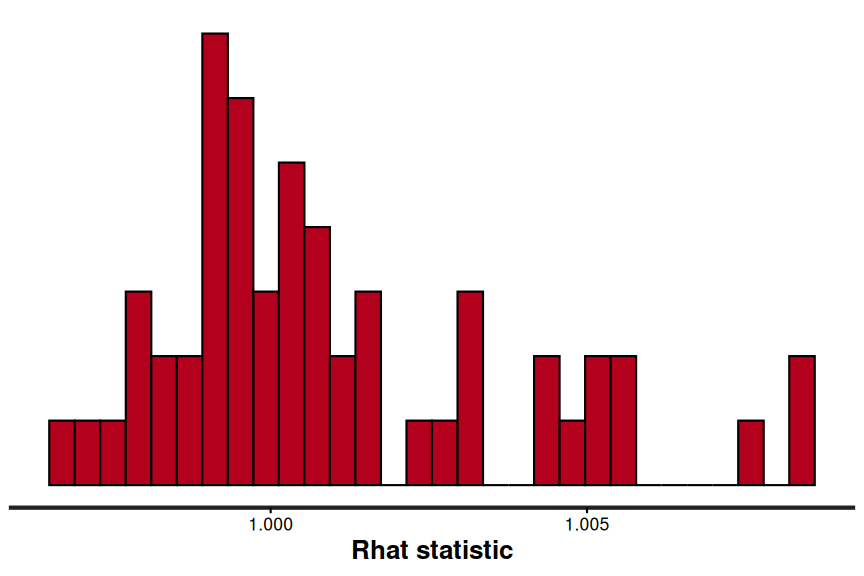

```r
ltmp_sub_brm1b$fit |> stan_rhat()
```

All Rhat values are below 1.05, suggesting the chains have converged.

- stan_ess (number of effective samples): the ratio of the number of effective samples (those not rejected by the sampler) to the number of samples provides an indication of the effectiveness (and efficiency) of the MCMC sampler. Ratios that are less than 0.5 for a parameter suggest that the sampler spent considerable time in difficult areas of the sampling domain and rejected more than half of the samples (replacing them with the previous effective sample).

  If the ratios are low, tightening the priors may help.

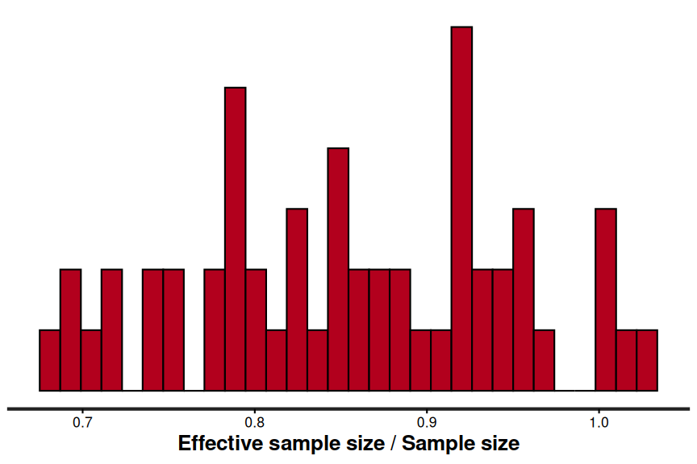

```r
ltmp_sub_brm1b$fit |> stan_ess()
```

Ratios all very high.

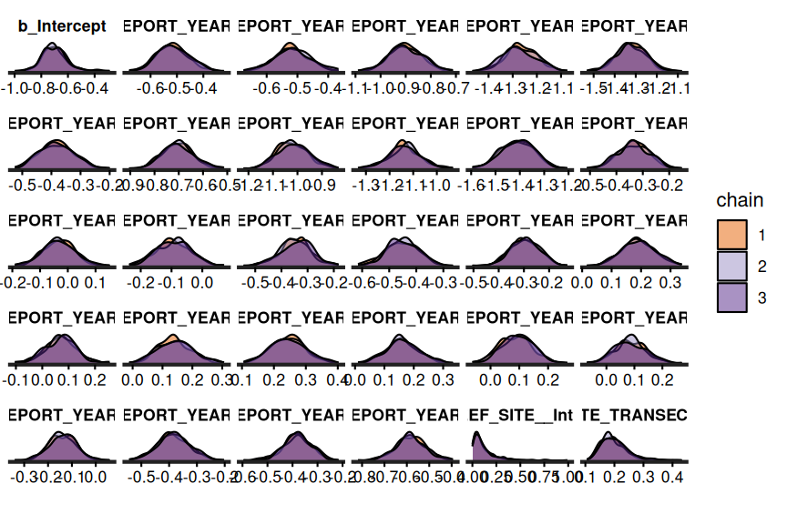

```r
ltmp_sub_brm1b$fit |>
    stan_dens(separate_chains = TRUE, pars = pars)
```

# 10 Model validation

**brms**

**pp check**

Post predictive checks provide additional diagnostics about the fit of the model. Specifically, they provide a comparison between predictions drawn from the model and the observed data used to train the model.

**See list of available diagnostics by name**

```r
available_ppc()
```

```
bayesplot PPC module:
  ppc_bars
  ppc_bars_grouped
  ppc_boxplot
  ppc_calibration
  ppc_calibration_grouped
  ppc_calibration_overlay
  ppc_calibration_overlay_grouped
  ppc_dens
  ppc_dens_overlay
  ppc_dens_overlay_grouped
  ppc_dots
  ppc_ecdf_overlay
  ppc_ecdf_overlay_grouped
  ppc_error_binned
  ppc_error_hist
  ppc_error_hist_grouped
  ppc_error_scatter
  ppc_error_scatter_avg
  ppc_error_scatter_avg_grouped
  ppc_error_scatter_avg_vs_x
  ppc_freqpoly
  ppc_freqpoly_grouped
  ppc_hist
  ppc_intervals
  ppc_intervals_grouped
  ppc_km_overlay
  ppc_km_overlay_grouped
  ppc_loo_calibration
  ppc_loo_calibration_grouped
  ppc_loo_intervals
  ppc_loo_pit_ecdf
  ppc_loo_pit_overlay
  ppc_loo_pit_qq
  ppc_loo_ribbon
  ppc_pit_ecdf
  ppc_pit_ecdf_grouped
  ppc_ribbon
  ppc_ribbon_grouped
  ppc_rootogram
  ppc_rootogram_grouped
  ppc_scatter
  ppc_scatter_avg
  ppc_scatter_avg_grouped
  ppc_stat
  ppc_stat_2d
  ppc_stat_freqpoly
  ppc_stat_freqpoly_grouped
  ppc_stat_grouped
  ppc_violin_grouped
```

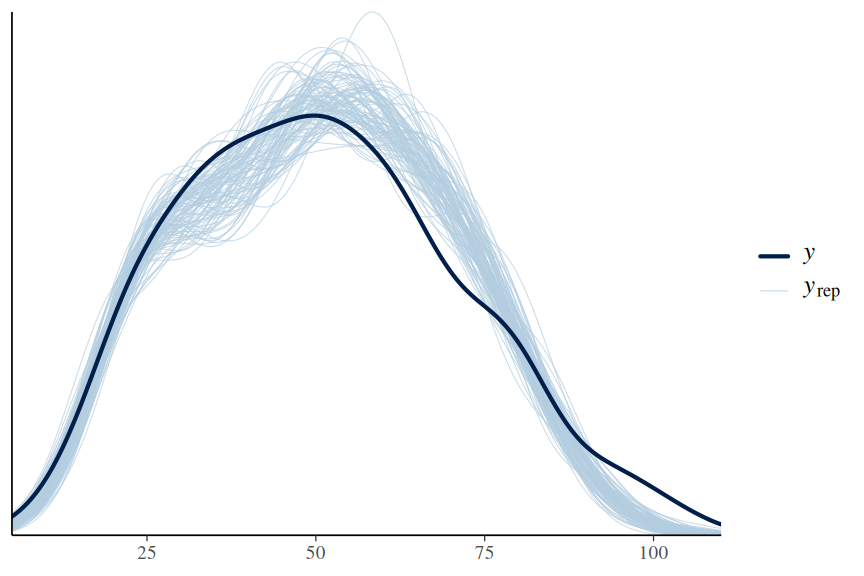

```r
ltmp_sub_brm1b |> pp_check(type = 'dens_overlay', ndraws = 100)
```

The model draws appear to be consistent with the observed data.

- error_scatter_avg: this plots the observed values against the average residuals. Similar to a residual plot, we do not want to see any patterns in this plot. Note, this is not really that useful for models that involve a binomial response

```r
## ltmp_sub_brm1b %>% pp_check(type = 'error_scatter_avg')
```

This is not really interpretable

- intervals: plots the observed data overlayed on top of posterior predictions associated with each level of the predictor. Ideally, the observed data should all fall within the predictive intervals.

```
Using all posterior draws for ppc type 'intervals' by default.
```

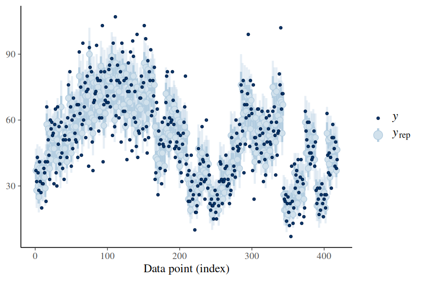

```r
ltmp_sub_brm1b %>% pp_check(group = 'REEF', type = 'intervals')
```

The `shinystan` package allows the full suite of MCMC diagnostics and posterior predictive checks to be accessed via a web interface.

```r
#library(shinystan)
#launch_shinystan(ltmp_sub_brm1b)
```

**DHARMa residuals**

DHARMa residuals provide very useful diagnostics. Unfortunately, we cannot directly use the `simulateResiduals()` function to generate the simulated residuals. However, if we are willing to calculate some of the components yourself, we can still obtain the simulated residuals from the fitted stan model.

We need to supply:

- simulated (predicted) responses associated with each observation.
- observed values
- fitted (predicted) responses (averaged) associated with each observation

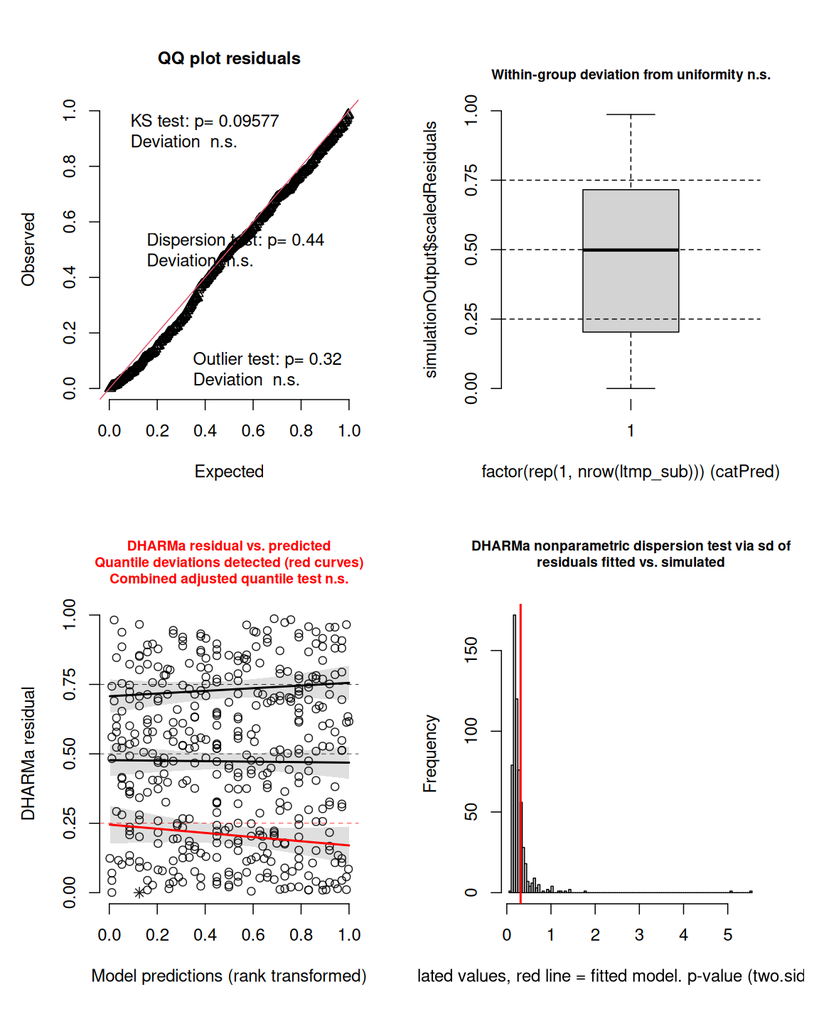

```r
ltmp_sub_resids <- make_brms_dharma_res(ltmp_sub_brm1b, integerResponse = TRUE)
wrap_elements(~testUniformity(ltmp_sub_resids)) +
               wrap_elements(~plotResiduals(ltmp_sub_resids, form = factor(rep(1, nrow(ltmp_sub))))) +
               wrap_elements(~plotResiduals(ltmp_sub_resids, quantreg = TRUE)) +
               wrap_elements(~testDispersion(ltmp_sub_resids))
```

```r
## resids2 <- recalculateResiduals(ltmp_sub_resids, group = unique(ltmp_sub$fREPORT_YEAR))
## testTemporalAutocorrelation(resids2, time = unique(ltmp_sub$fREPORT_YEAR))

## library(geoR)
## autocor_check(ltmp_sub, ltmp_sub_brm1b, variable =  "fREPORT_YEAR", n.sim =  250)
```

# 11 Model investigation

**brms**

**summary**

```r
ltmp_sub_brm1b %>% summary()
```

```
 Family: binomial
  Links: mu = logit
Formula: n.points | trials(total.points) ~ fREPORT_YEAR + (1 | REEF_SITE) + (1 | REEF_SITE_TRANSECT)
   Data: ltmp_sub (Number of observations: 418)
  Draws: 3 chains, each with iter = 3000; warmup = 1000; thin = 10;
         total post-warmup draws = 600

Multilevel Hyperparameters:
~REEF_SITE (Number of levels: 3)
              Estimate Est.Error l-95% CI u-95% CI Rhat Bulk_ESS Tail_ESS
sd(Intercept)     0.11      0.12     0.00     0.45 1.00      567      581

~REEF_SITE_TRANSECT (Number of levels: 15)
              Estimate Est.Error l-95% CI u-95% CI Rhat Bulk_ESS Tail_ESS
sd(Intercept)     0.20      0.05     0.13     0.32 1.00      521      545

Regression Coefficients:
                 Estimate Est.Error l-95% CI u-95% CI Rhat Bulk_ESS Tail_ESS
Intercept           -0.70      0.10    -0.87    -0.47 1.00      495      488
fREPORT_YEAR2021    -0.51      0.06    -0.63    -0.39 1.00      423      511
fREPORT_YEAR2020    -0.52      0.06    -0.63    -0.40 1.00      560      591
fREPORT_YEAR2019    -0.90      0.07    -1.02    -0.77 1.01      513      488
fREPORT_YEAR2018    -1.27      0.07    -1.40    -1.14 1.00      555      488
fREPORT_YEAR2017    -1.32      0.07    -1.45    -1.19 1.00      421      414
fREPORT_YEAR2016    -0.38      0.06    -0.48    -0.28 1.00      501      551
fREPORT_YEAR2015    -0.70      0.06    -0.82    -0.58 1.00      461      468
fREPORT_YEAR2014    -1.02      0.06    -1.14    -0.88 1.00      478      568
fREPORT_YEAR2013    -1.14      0.07    -1.28    -1.00 1.00      534      517
fREPORT_YEAR2012    -1.41      0.07    -1.55    -1.28 1.00      574      479
fREPORT_YEAR2011    -0.33      0.06    -0.45    -0.22 1.00      473      552
fREPORT_YEAR2010    -0.03      0.06    -0.14     0.08 1.00      538      548
fREPORT_YEAR2009    -0.09      0.06    -0.20     0.01 1.00      421      536
fREPORT_YEAR2008    -0.35      0.06    -0.47    -0.22 1.01      457      589
fREPORT_YEAR2007    -0.45      0.06    -0.57    -0.34 1.00      572      551
fREPORT_YEAR2006    -0.30      0.06    -0.40    -0.19 1.01      426      521
fREPORT_YEAR2005     0.19      0.06     0.08     0.30 1.00      554      518
fREPORT_YEAR2004     0.07      0.06    -0.04     0.19 1.00      499      530
fREPORT_YEAR2003     0.14      0.06     0.04     0.26 1.00      497      530
fREPORT_YEAR2002     0.24      0.05     0.14     0.35 1.00      431      515
fREPORT_YEAR2001     0.16      0.06     0.06     0.28 1.00      490      514
fREPORT_YEAR2000     0.09      0.06    -0.01     0.19 1.01      470      587
fREPORT_YEAR1999     0.09      0.05    -0.02     0.20 1.00      475      519
fREPORT_YEAR1998    -0.14      0.06    -0.25    -0.03 1.00      539      551
fREPORT_YEAR1997    -0.38      0.06    -0.50    -0.27 1.00      522      522
fREPORT_YEAR1996    -0.38      0.06    -0.50    -0.28 1.00      453      591
fREPORT_YEAR1995    -0.58      0.07    -0.72    -0.45 1.00      494      586

Draws were sampled using sampling(NUTS). For each parameter, Bulk_ESS
and Tail_ESS are effective sample size measures, and Rhat is the potential
scale reduction factor on split chains (at convergence, Rhat = 1).
```

**as_draws_df (posteriors)**

```r
ltmp_sub_brm1b |> as_draws_df()
```

```
# A draws_df: 200 iterations, 3 chains, and 55 variables
   b_Intercept b_fREPORT_YEAR2021 b_fREPORT_YEAR2020 b_fREPORT_YEAR2019
1        -0.77              -0.54              -0.48              -0.83
2        -0.70              -0.47              -0.57              -0.91
3        -0.72              -0.51              -0.44              -0.93
4        -0.75              -0.52              -0.50              -0.89
5        -0.79              -0.49              -0.51              -0.84
6        -0.77              -0.50              -0.54              -0.95
7        -0.72              -0.43              -0.42              -0.79
8        -0.68              -0.49              -0.47              -0.91
9        -0.75              -0.57              -0.53              -0.80
10       -0.69              -0.41              -0.47              -0.91
   b_fREPORT_YEAR2018 b_fREPORT_YEAR2017 b_fREPORT_YEAR2016 b_fREPORT_YEAR2015
1                -1.2               -1.3              -0.36              -0.64
2                -1.3               -1.3              -0.41              -0.68
3                -1.4               -1.3              -0.40              -0.71
4                -1.3               -1.4              -0.45              -0.67
5                -1.3               -1.3              -0.30              -0.64
6                -1.2               -1.3              -0.42              -0.76
7                -1.1               -1.3              -0.30              -0.62
8                -1.3               -1.4              -0.37              -0.66
9                -1.2               -1.3              -0.41              -0.78
10               -1.2               -1.3              -0.34              -0.68
# ... with 590 more draws, and 47 more variables
# ... hidden reserved variables {'.chain', '.iteration', '.draw'}
```

```r
ltmp_sub_brm1b |>
    as_draws_df() |>
    dplyr::select(matches("^b_.*|^sd_.*")) |>
    mutate(Intercept = plogis(b_Intercept)) |>
    mutate(across(matches("b_.*"), exp)) |>
    summarise_draws(
        median,
        HDInterval::hdi,
        Pl = ~ mean(.x < 1),
        Pg = ~ mean(.x > 1),
        rhat,
        ess_bulk
    ) |>
  as.data.frame()
```

```
                           variable     median        lower     upper
1                       b_Intercept 0.49432801 0.4085414433 0.5982671
2                b_fREPORT_YEAR2021 0.59580558 0.5343127104 0.6737663
3                b_fREPORT_YEAR2020 0.59520945 0.5314914278 0.6688820
4                b_fREPORT_YEAR2019 0.40533951 0.3612922576 0.4620528
5                b_fREPORT_YEAR2018 0.27975114 0.2462925441 0.3199141
6                b_fREPORT_YEAR2017 0.26531772 0.2341026335 0.3048021
7                b_fREPORT_YEAR2016 0.68154706 0.6150022767 0.7567686
8                b_fREPORT_YEAR2015 0.49348216 0.4434759935 0.5617453
9                b_fREPORT_YEAR2014 0.35982163 0.3146174313 0.4071279
10               b_fREPORT_YEAR2013 0.32080780 0.2748962098 0.3632876
11               b_fREPORT_YEAR2012 0.24445361 0.2147787532 0.2776069
12               b_fREPORT_YEAR2011 0.71526058 0.6404377087 0.8003199
13               b_fREPORT_YEAR2010 0.96824603 0.8502252575 1.0665016
14               b_fREPORT_YEAR2009 0.90954411 0.8190463158 1.0096978
```

[output cut: 49 more lines]

**\(R^2\)**

```r
ltmp_sub_brm1b |>
    bayes_R2(re.form = NA, summary=FALSE) |>
    median_hdci()
```

```
          y      ymin      ymax .width .point .interval
1 0.6757641 0.6382197 0.7146766   0.95 median      hdci
```

```r
ltmp_sub_brm1b |>
    bayes_R2(re.form = ~(1|REEF_SITE), summary=FALSE) |>
    median_hdci()
```

```
          y      ymin      ymax .width .point .interval
1 0.6706741 0.6433291 0.6982757   0.95 median      hdci
```

```r
ltmp_sub_brm1b |>
    bayes_R2(re.form = ~(1|REEF_SITE) + (1| REEF_SITE_TRANSECT), summary=FALSE) |>
    median_hdci()
```

```
          y      ymin      ymax .width .point .interval
1 0.7686449 0.7575495 0.7801594   0.95 median      hdci
```

# 12 Further mnvestigations

**brms**

**Cellmeans**

Lets start by calculating the cell means

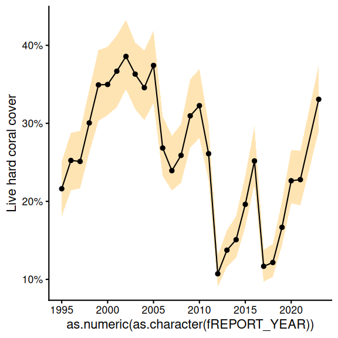

```r
ltmp_sub_brm1b |>
    emmeans(~fREPORT_YEAR, type = "response") |>
    as.data.frame() |>
    mutate(
        fREPORT_YEAR = factor(fREPORT_YEAR, levels = rev(levels(fREPORT_YEAR))),
    ) |>
    ggplot(aes(y = prob, x = as.numeric(as.character(fREPORT_YEAR)))) +
    geom_ribbon(aes(ymin = lower.HPD, ymax = upper.HPD), fill = "orange", alpha = 0.3) +
    geom_line() +
    geom_point() +
    theme_classic() +
    scale_y_continuous("Live hard coral cover", label = scales::percent_format())
```

**Effects**

```r
newdata <- list(fREPORT_YEAR = c(2011, 2012))
ltmp_sub_brm1b |>
  emmeans(~fREPORT_YEAR,
    at = newdata,
    type = "response"
    )
```

```
 fREPORT_YEAR  prob lower.HPD upper.HPD
         2011 0.261    0.2271     0.299
         2012 0.107    0.0903     0.130

Point estimate displayed: median
Results are back-transformed from the logit scale
HPD interval probability: 0.95
```

```r
ltmp_sub_brm1b |>
  emmeans(~fREPORT_YEAR,
    at = newdata,
    type = "response"
  ) |>
  pairs(reverse = TRUE)
```

```
 contrast                            odds.ratio lower.HPD upper.HPD
 fREPORT_YEAR2012 / fREPORT_YEAR2011      0.341     0.295     0.391

Point estimate displayed: median
Results are back-transformed from the log odds ratio scale
HPD interval probability: 0.95
```

```r
newdata <- list(fREPORT_YEAR = c(2000:2005, 2012:2013))
cmat <- cbind(c(rep(1 / 6, 6), rep(-1 / 2, 2)))
ltmp_sub_brm1b |>
    emmeans(~fREPORT_YEAR,
        at = newdata,
        type = "response"
    ) |>
    regrid() |>
  contrast(method = list(fREPORT_YEAR = cmat))
```

```
 contrast     estimate lower.HPD upper.HPD
 fREPORT_YEAR    0.242     0.221     0.272

Point estimate displayed: median
HPD interval probability: 0.95
```

```r
ltmp_sub_brm1b |>
    emmeans(~fREPORT_YEAR,
        at = list(fREPORT_YEAR = c(2011, 2012)),
        type = "link"
    ) |>
    pairs(reverse = TRUE) |>
    tidy_draws() |>
    exp() |>
    summarise_draws(
      median,
      HDInterval::hdi,
      Pl = ~ mean(.x < 1),
      Pg = ~ mean(.x > 1)
    )
```

```
# A tibble: 1 × 6
  variable                                     median lower upper    Pl    Pg
  <chr>                                         <dbl> <dbl> <dbl> <dbl> <dbl>
1 contrast fREPORT_YEAR2012 - fREPORT_YEAR2011  0.341 0.295 0.391     1     0
```

```r
cmat <- cbind(c(rep(-1 / 7, 7), 1))
ltmp_sub_brm1b |>
    emmeans(~fREPORT_YEAR,
        at = list(fREPORT_YEAR = c(1999:2005, 2012)),
        type = "response"
    ) |>
    contrast(method = list(fREPORT_YEAR = cmat))
```

```
 contrast     odds.ratio lower.HPD upper.HPD
 fREPORT_YEAR      0.212     0.189     0.237

Point estimate displayed: median
Results are back-transformed from the log odds ratio scale
HPD interval probability: 0.95
```

```r
ltmp_sub_brm1b |>
    emmeans(~fREPORT_YEAR,
        at = list(fREPORT_YEAR = c(1999:2005, 2012)),
        type = "response"
    ) |>
    regrid() |>
    contrast(method = list(fREPORT_YEAR = cmat))
```

```
 contrast     estimate lower.HPD upper.HPD
 fREPORT_YEAR   -0.254    -0.287    -0.232

Point estimate displayed: median
HPD interval probability: 0.95
```

# 13 As a GAM

sds- wiggliness parameter

- sds(sx_1) is the sd of the smooth weights (spline coefficients).
  - This determines the amount of ‘wiggliness’, and is analogous way to how the sd of group-level effects in a varying slopes and intercepts model determine the amount of variability among groups in slopes and intercepts.
  - However, the actual numeric value of the sds() is not very practically interpretable, because thinking about the variance of smooth weights for any given data and model seems abstract to me.
  - However, if the value is around zero, then this is like ‘complete-pooling’ of the basis functions, which means that there isn’t much added value of more than a single basis function.
- sx_1 is the unpenalized weight (ie coefficient) for one of the “natural” parameterized basis functions.
  - these are like betas,in that they are like a weight in the model (the influence of the spline)
  - The rest of the basis functions are like varying effects.
  - Again, because the actual numeric value of sxs_1 is the value for the unpenalized coefficient for one of the basis functions.
  - his wouldn’t seem to have a lot of practically interpretable meaning just from viewing this number.

**Visualise basis functions**

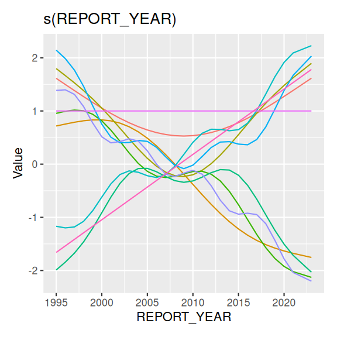

```r
gratia::basis(s(REPORT_YEAR),  data = ltmp_sub) |> gratia::draw()
```

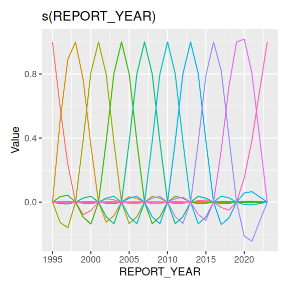

```r
gratia::basis(s(REPORT_YEAR, bs='cr'),  data = ltmp_sub) |> gratia::draw()
```

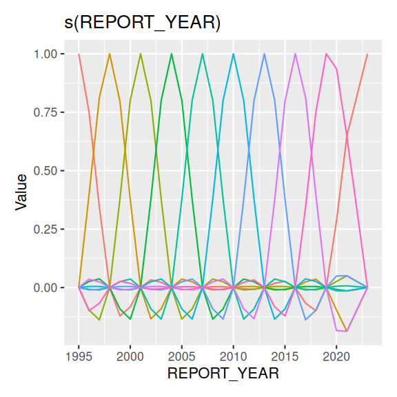

```r
gratia::basis(s(REPORT_YEAR, bs='cc'),  data = ltmp_sub) |> gratia::draw()
```

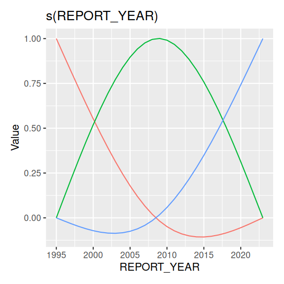

```r
gratia::basis(s(REPORT_YEAR, bs='cr', k = 3),  data = ltmp_sub) |> gratia::draw()
```

```r
data.frame(mgcv::smoothCon(s(REPORT_YEAR), data = ltmp_sub)[[1]]$X) |>
    head()
```

```
        X1        X2       X3        X4       X5        X6       X7      X8 X9
1 1.613482 0.7174855 1.797952 0.9553312 -1.98971 -1.168654 2.144241 1.38704  1
2 1.613482 0.7174855 1.797952 0.9553312 -1.98971 -1.168654 2.144241 1.38704  1
3 1.613482 0.7174855 1.797952 0.9553312 -1.98971 -1.168654 2.144241 1.38704  1
4 1.613482 0.7174855 1.797952 0.9553312 -1.98971 -1.168654 2.144241 1.38704  1
5 1.613482 0.7174855 1.797952 0.9553312 -1.98971 -1.168654 2.144241 1.38704  1
6 1.613482 0.7174855 1.797952 0.9553312 -1.98971 -1.168654 2.144241 1.38704  1
        X10
1 -1.660199
2 -1.660199
3 -1.660199
4 -1.660199
5 -1.660199
6 -1.660199
```

```r
## data.frame(mgcv::smoothCon(s(REPORT_YEAR, k=3),  data=ltmp_sub)[[1]]$REPORT_YEAR) |>
##   bind_cols(ltmp_sub)
```

**Define formula and priors**

```r
ltmp_form <- bf(
    n.points | trials(total.points) ~ s(REPORT_YEAR) +
        (1 | REEF_SITE) + (1 | REEF_SITE_TRANSECT),
    family = binomial(link = "logit")
)
get_prior(ltmp_form, data = ltmp_sub)
```

```
                prior     class           coef              group resp dpar
               (flat)         b
               (flat)         b sREPORT_YEAR_1
 student_t(3, 0, 2.5) Intercept
 student_t(3, 0, 2.5)        sd
 student_t(3, 0, 2.5)        sd                         REEF_SITE
 student_t(3, 0, 2.5)        sd      Intercept          REEF_SITE
 student_t(3, 0, 2.5)        sd                REEF_SITE_TRANSECT
 student_t(3, 0, 2.5)        sd      Intercept REEF_SITE_TRANSECT
 student_t(3, 0, 2.5)       sds
 student_t(3, 0, 2.5)       sds s(REPORT_YEAR)
 nlpar lb ub tag       source
                      default
                 (vectorized)
                      default
        0             default
        0        (vectorized)
        0        (vectorized)
        0        (vectorized)
        0        (vectorized)
        0             default
        0        (vectorized)
```

```r
## - b (beta) is the unpenalized weight (ie coefficient) for one of the
##   “natural” parameterized basis functions.
##   - these are like betas,in that they are like a weight in the model (the influence of the spline)
##   - The rest of the basis functions are like varying effects.
##   - Again, because the actual numeric value of sxs_1 is the value for
##     the unpenalized coefficient for one of the basis functions.
##   - his wouldn’t seem to have a lot of practically interpretable
##     meaning just from viewing this number.

## - sds is the sd of the smooth weights (spline coefficients).
##   - This determines the amount of ‘wiggliness’, and is analogous way
##     to how the sd of group-level effects in a varying slopes and
##     intercepts model determine the amount of variability among groups
##     in slopes and intercepts.
##   - However, the actual numeric value of the sds() is not very
##     practically interpretable, because thinking about the variance of
##     smooth weights for any given data and model seems abstract to me.
##   - However, if the value is around zero, then this is like
##     ‘complete-pooling’ of the basis functions, which means that there
##     isn’t much added value of more than a single basis function.

ltmp_sub |>
  summarise(
    Median = median(qlogis(n.points / total.points)),
    MAD = mad(qlogis(n.points / total.points))
  )
```

```
# A tibble: 1 × 2
  Median   MAD
   <dbl> <dbl>
1  -1.10 0.579
```

```r
priors <- prior(normal(-1.1, 0.6), class = "Intercept") +
  prior(normal(0, 1), class = 'b') +
  prior(student_t(3, 0, 0.6), class = 'sd') +
  prior(student_t(3, 0, 5), class = 'sds')
```

**Fit model**

```r
ltmp_sub_brm2 <- brm(ltmp_form,
  data = ltmp_sub,
  prior = priors,
  sample_prior = 'yes',
  iter = 5000,
  warmup = 1000,
  chains = 3, cores = 3,
  thin = 10,
  refresh = 100,
  seed = 123,
  control = list(adapt_delta = 0.99, max_treedepth = 20),
  backend = "rstan"
)
```

**Partial plots**

```
Ignoring unknown labels:
• fill : "NA"
• colour : "NA"
Ignoring unknown labels:
• fill : "NA"
• colour : "NA"
```

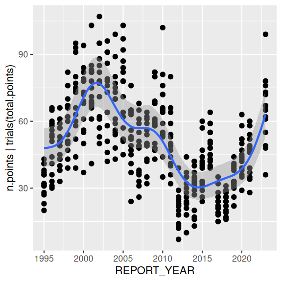

```r
ltmp_sub_brm2 |>
  conditional_effects(conditions = data.frame(total.points = 200)) |>
  plot(points = TRUE)
```

```
Ignoring unknown labels:
• fill : "NA"
• colour : "NA"
Ignoring unknown labels:
• fill : "NA"
• colour : "NA"
```

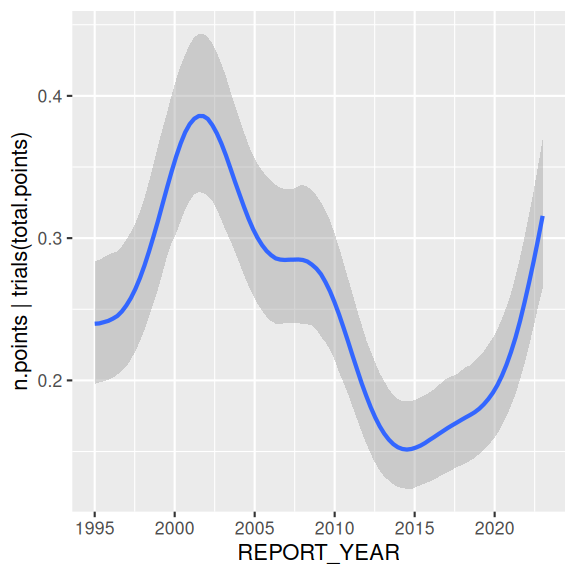

```r
ltmp_sub_brm2 |>
  conditional_effects(conditions = data.frame(total.points = 1)) |>
  plot(points = FALSE)
```

**MCMC sampling diagnostics**

```r
pars <- ltmp_sub_brm2 |>
    get_variables() |>
    str_subset("^b_.*|^sd.*")
pars
```

```
[1] "b_Intercept"                      "sd_REEF_SITE__Intercept"
[3] "sd_REEF_SITE_TRANSECT__Intercept" "sds_sREPORT_YEAR_1"
```

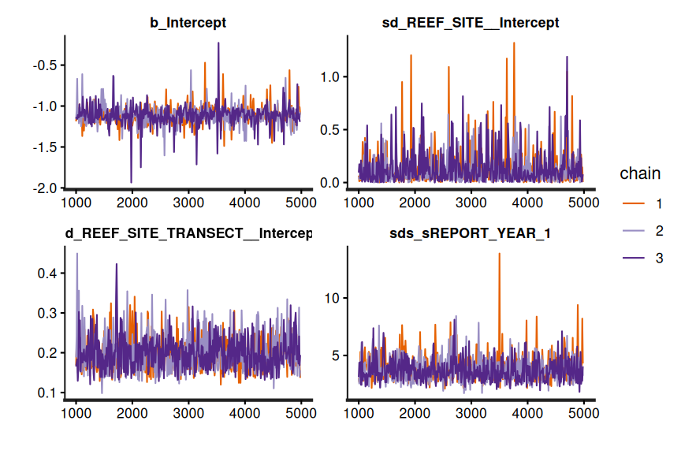

```r
ltmp_sub_brm2$fit |>
    stan_trace(pars = pars)
```

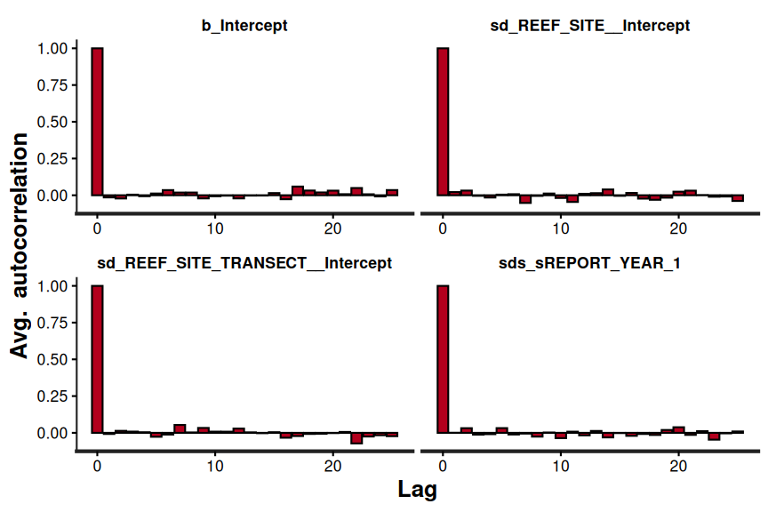

```r
ltmp_sub_brm2$fit |>
    stan_ac(pars = pars)
```

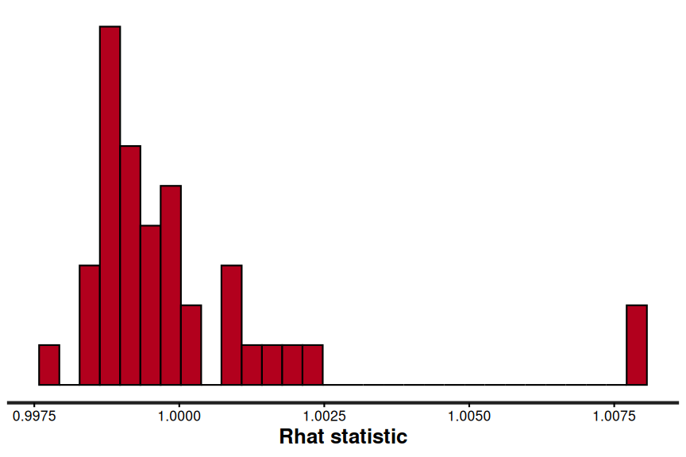

```r
ltmp_sub_brm2$fit |> stan_rhat()
```

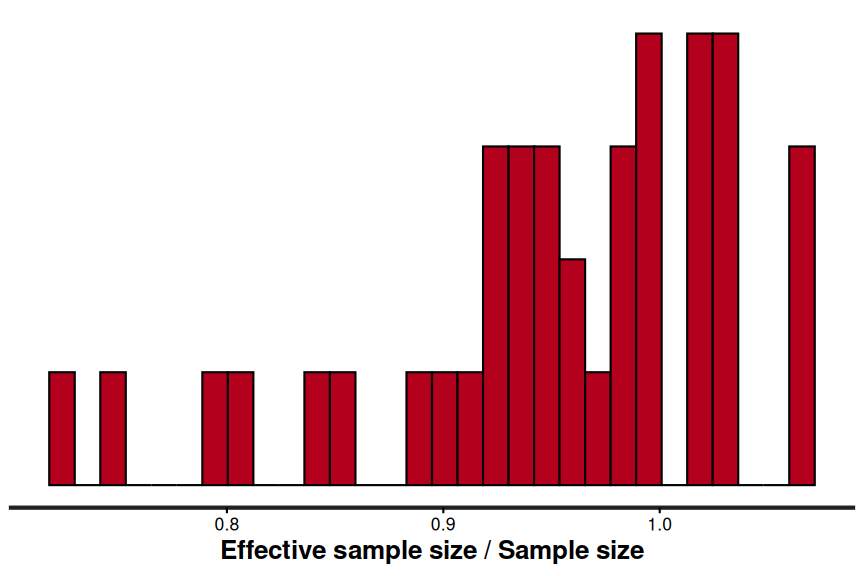

```r
ltmp_sub_brm2$fit |> stan_ess()
```

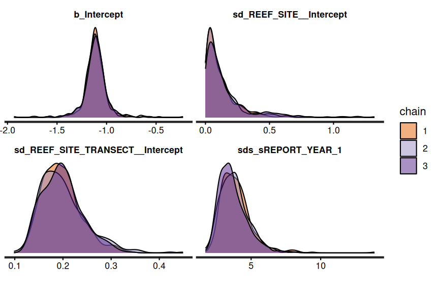

```r
ltmp_sub_brm2$fit |>
    stan_dens(separate_chains = TRUE, pars = pars)
```

**Model validation**

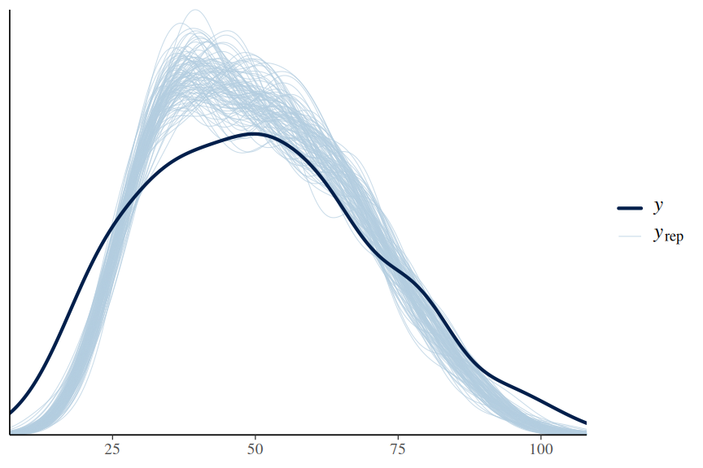

```r
ltmp_sub_brm2 |> pp_check(type = 'dens_overlay', ndraws = 100)
```

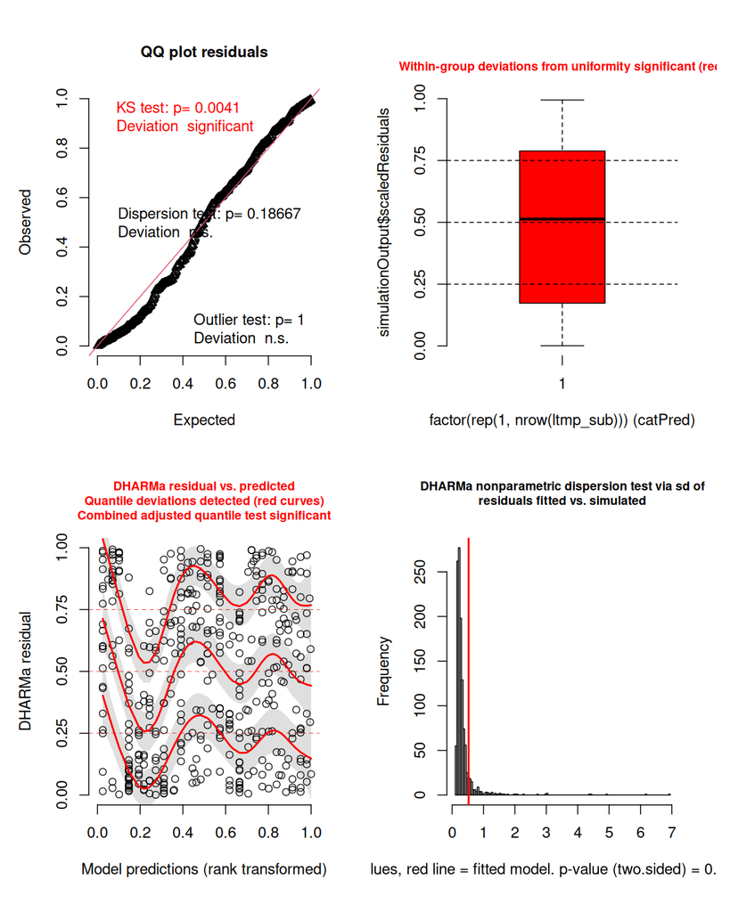

```r
ltmp_sub_resids <- make_brms_dharma_res(ltmp_sub_brm2, integerResponse = TRUE)
wrap_elements(~testUniformity(ltmp_sub_resids)) +
               wrap_elements(~plotResiduals(ltmp_sub_resids, form = factor(rep(1, nrow(ltmp_sub))))) +
               wrap_elements(~plotResiduals(ltmp_sub_resids, quantreg = TRUE)) +
               wrap_elements(~testDispersion(ltmp_sub_resids))
```

**Model investigation**

```r
ltmp_sub_brm2 |> summary()
```

```
 Family: binomial
  Links: mu = logit
Formula: n.points | trials(total.points) ~ s(REPORT_YEAR) + (1 | REEF_SITE) + (1 | REEF_SITE_TRANSECT)
   Data: ltmp_sub (Number of observations: 418)
  Draws: 3 chains, each with iter = 5000; warmup = 1000; thin = 10;
         total post-warmup draws = 1200

Smoothing Spline Hyperparameters:
                    Estimate Est.Error l-95% CI u-95% CI Rhat Bulk_ESS Tail_ESS
sds(sREPORT_YEAR_1)     3.81      1.07     2.33     6.25 1.01      969     1081

Multilevel Hyperparameters:
~REEF_SITE (Number of levels: 3)
              Estimate Est.Error l-95% CI u-95% CI Rhat Bulk_ESS Tail_ESS
sd(Intercept)     0.13      0.16     0.00     0.56 1.00     1183     1109

~REEF_SITE_TRANSECT (Number of levels: 15)
              Estimate Est.Error l-95% CI u-95% CI Rhat Bulk_ESS Tail_ESS
sd(Intercept)     0.20      0.04     0.14     0.30 1.00     1299     1029

Regression Coefficients:
               Estimate Est.Error l-95% CI u-95% CI Rhat Bulk_ESS Tail_ESS
Intercept         -1.11      0.12    -1.34    -0.88 1.00     1055     1108
sREPORT_YEAR_1     6.42      0.67     5.12     7.73 1.00     1132     1080

Draws were sampled using sampling(NUTS). For each parameter, Bulk_ESS
and Tail_ESS are effective sample size measures, and Rhat is the potential
scale reduction factor on split chains (at convergence, Rhat = 1).
```

```r
## sds- wiggliness parameter
## - sds(sx_1) is the sd of the smooth weights (spline coefficients).

##   - This determines the amount of ‘wiggliness’, and is analogous way
##     to how the sd of group-level effects in a varying slopes and
##     intercepts model determine the amount of variability among groups
##     in slopes and intercepts.
##   - However, the actual numeric value of the sds() is not very
##     practically interpretable, because thinking about the variance of
##     smooth weights for any given data and model seems abstract to me.
##   - However, if the value is around zero, then this is like
##     ‘complete-pooling’ of the basis functions, which means that there
##     isn’t much added value of more than a single basis function.

## - sx_1 is the unpenalized weight (ie coefficient) for one of the
##   “natural” parameterized basis functions.
##   - these are like betas,in that they are like a weight in the model (the influence of the spline)
##   - The rest of the basis functions are like varying effects.
##   - Again, because the actual numeric value of sxs_1 is the value for
##     the unpenalized coefficient for one of the basis functions.
##   - his wouldn’t seem to have a lot of practically interpretable
##     meaning just from viewing this number.

## Intercept - plogis(-1.08) = 0.253 (estimated coral cover at centered year)
## sREPORT_YEAR_1 (spline coefficient) - purely internal coefficient for the spline basis function.  Not interpretable in itself.
## sds(sREPORT_YEAR_1) - spline sd. degree of wiggliness - larger the value, more wiggly the spline.  This is a measure of how much the spline is allowed to vary.  If this is close to zero, then the spline is essentially flat (no wiggle).  If this is large, then the spline can wiggle a lot.

## the temporal component is the dominant source of structural variation (3.75 vs 0.11 and 0.2)

## The estimated mean proportion was 0.25 (95% CrI: 0.22-0.31). Temporal variation was strongly supported, with the spline smoothness parameter well above zero (sds = 3.75, 95% CrI: 2.25-6.34), indicating substantial non-linear change through time. Variability among reef sites was small and uncertain (SD = 0.11, 95% CrI: 0.00-0.44), whereas transects exhibited clearer heterogeneity (SD = 0.20, 95% CrI: 0.13-0.30).
```

**Summary figures**

```
Setting all 'trials' variables to 1 by default if not specified otherwise.
```

```
Ignoring unknown labels:
• fill : "NA"
• colour : "NA"
Ignoring unknown labels:
• fill : "NA"
• colour : "NA"
```

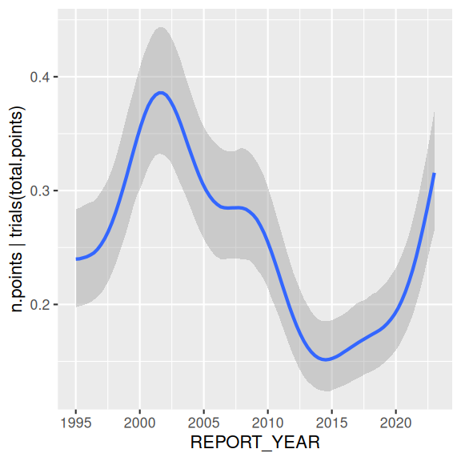

```
Ignoring unknown labels:
• fill : "NA"
• colour : "NA"
```

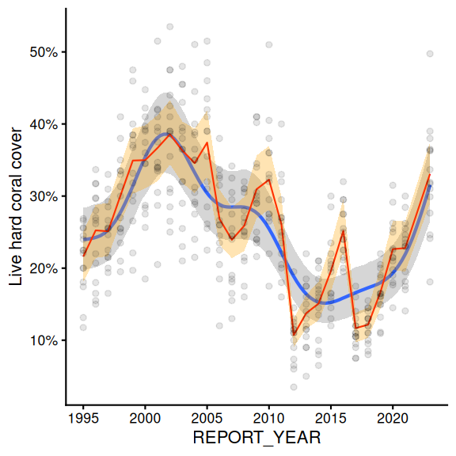

```r
ltmp_glmm <- ltmp_sub_brm1b |>
    emmeans(~fREPORT_YEAR, type = "response") |>
    as.data.frame() |>
    mutate(
        fREPORT_YEAR = factor(fREPORT_YEAR, levels = rev(levels(fREPORT_YEAR))),
        REPORT_YEAR = as.numeric(as.character(fREPORT_YEAR))
    )
ltmp_sub_brm2 |>
  conditional_effects() |>
  plot() |>
  _[[1]] +
  geom_line(data = ltmp_glmm, inherit.aes = FALSE,
    aes(y = prob, x = REPORT_YEAR), colour = "red") +
  geom_ribbon(data = ltmp_glmm, inherit.aes = FALSE,
    aes(y = prob, x = REPORT_YEAR,
      min = lower.HPD, ymax = upper.HPD), fill = "orange", alpha = 0.3) +
  geom_point(data = ltmp_sub,
    aes(y = n.points / total.points, x = REPORT_YEAR), inherit.aes = FALSE, alpha = 0.1) +
  theme_classic() +
  scale_y_continuous("Live hard coral cover", label = scales::percent_format())
```

```
Setting all 'trials' variables to 1 by default if not specified otherwise.
Ignoring unknown labels:
• colour : "NA"Ignoring unknown labels:
• colour : "NA"
```

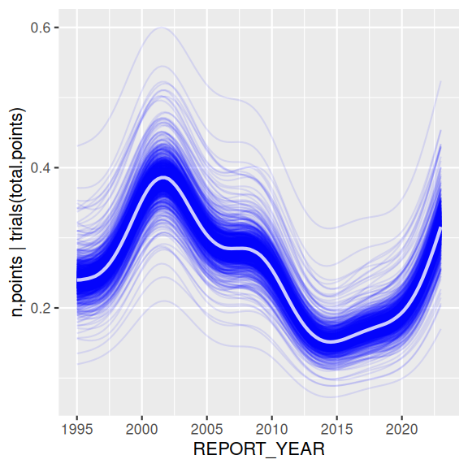

```
Ignoring unknown labels:
• colour : "NA"
```

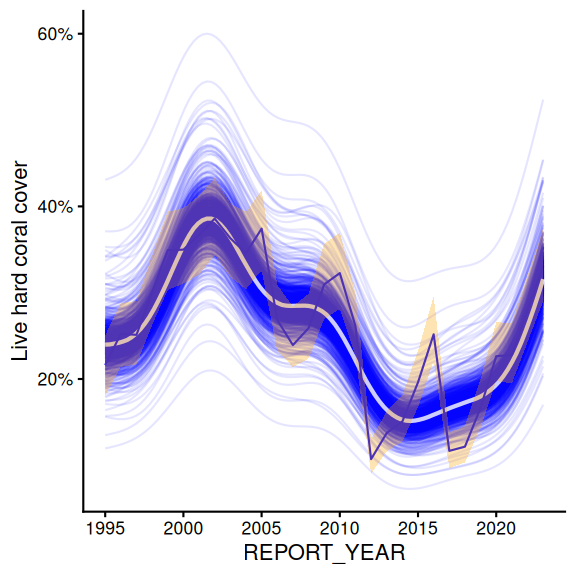

```r
ltmp_sub_brm2 |>
  conditional_effects(spaghetti = TRUE) |>
  plot() |>
  _[[1]] +
  geom_line(data = ltmp_glmm, inherit.aes = FALSE,
    aes(y = prob, x = REPORT_YEAR), colour = "blue") +
  geom_ribbon(data = ltmp_glmm, inherit.aes = FALSE,
    aes(y = prob, x = REPORT_YEAR,
      min = lower.HPD, ymax = upper.HPD), fill = "orange", alpha = 0.3) +
  theme_classic() +
  scale_y_continuous("Live hard coral cover", label = scales::percent_format())
```

## 13.1 As a Gaussian Process

**Define formula and priors**

```r
ltmp_form <- bf(
    n.points | trials(total.points) ~ gp(REPORT_YEAR) +
        (1 | REEF_SITE) + (1 | REEF_SITE_TRANSECT),
    family = binomial(link = "logit")
)
get_prior(ltmp_form, data = ltmp_sub)
```

```
                        prior     class          coef              group resp
         student_t(3, 0, 2.5) Intercept
                       (flat)    lscale
 inv_gamma(2.465473, 0.26722)    lscale gpREPORT_YEAR
         student_t(3, 0, 2.5)        sd
         student_t(3, 0, 2.5)        sd                        REEF_SITE
         student_t(3, 0, 2.5)        sd     Intercept          REEF_SITE
         student_t(3, 0, 2.5)        sd               REEF_SITE_TRANSECT
         student_t(3, 0, 2.5)        sd     Intercept REEF_SITE_TRANSECT
         student_t(3, 0, 2.5)      sdgp
         student_t(3, 0, 2.5)      sdgp gpREPORT_YEAR
 dpar nlpar lb ub tag       source
                           default
             0             default
             0             default
             0             default
             0        (vectorized)
             0        (vectorized)
             0        (vectorized)
             0        (vectorized)
             0             default
             0        (vectorized)
```

```r
## we are not putting a prior on wiggliness directly.  Rather we are putting a prior on
## GP hyperparameters.  The GP hyperparameters are the length scale and the standard deviation of the GP.  The length scale controls how quickly the GP can change (smaller values allow for more rapid changes), and the standard deviation controls how much variation there is in the GP.  We will put a prior on these hyperparameters.
#- lscale: the length scale of the GP. Distance over which the GP function is correlated.  Smaller values allow for more rapid changes in the GP.  Larger values allow for smoother changes in the GP.
#- sdgp: how much can the trend deviate from the intercept (on link scale)

ltmp_sub |>
    summarise(
        Median = median(qlogis(HC/100)),
        MAD = mad(qlogis(HC/100)),
        N = mean(total.points)
    )
```

```
# A tibble: 1 × 3
  Median   MAD     N
   <dbl> <dbl> <dbl>
1  -1.10 0.579  198.
```

```r
priors <- prior(normal(-1.1, 0.6), class = "Intercept") +
  prior(student_t(3, 0, 0.6), class = "sd") +
  ## prior(lognormal(log(5), 1), class = "lscale", coef = "gpREPORT_YEAR") +
  prior(exponential(5), class = "lscale", coef = "gpREPORT_YEAR") +
  prior(student_t(3, 0, 2), class = "sdgp")
```

**Fit model**

```r
ltmp_sub_brm3 <- brm(ltmp_form,
  data = ltmp_sub,
  prior = priors,
  sample_prior = 'yes',
  iter = 3000,
  warmup = 1000,
  chains = 3, cores = 3,
  thin = 10,
  refresh = 100,
  seed = 123,
  control = list(adapt_delta = 0.99, max_treedepth = 20),
  backend = "rstan"
)
```

**Partial plots**

```
Ignoring unknown labels:
• fill : "NA"
• colour : "NA"
Ignoring unknown labels:
• fill : "NA"
• colour : "NA"
```

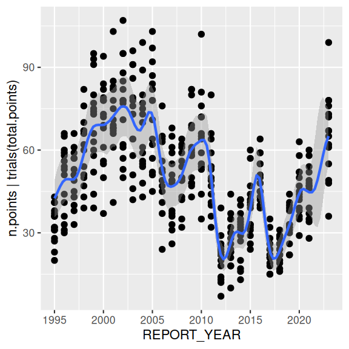

```r
ltmp_sub_brm3 |>
  conditional_effects(conditions = data.frame(total.points = 200)) |>
  plot(points = TRUE)
```

```
Ignoring unknown labels:
• fill : "NA"
• colour : "NA"
Ignoring unknown labels:
• fill : "NA"
• colour : "NA"
```

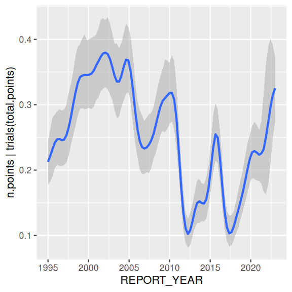

```r
ltmp_sub_brm3 |>
  conditional_effects(conditions = data.frame(total.points = 1)) |>
  plot(points = FALSE)
```

**MCMC sampling diagnostics**

```r
pars <- ltmp_sub_brm3 |>
    get_variables() |>
    str_subset("^b_.*|^sd.*")
pars
```

```
[1] "b_Intercept"                      "sd_REEF_SITE__Intercept"
[3] "sd_REEF_SITE_TRANSECT__Intercept" "sdgp_gpREPORT_YEAR"
```

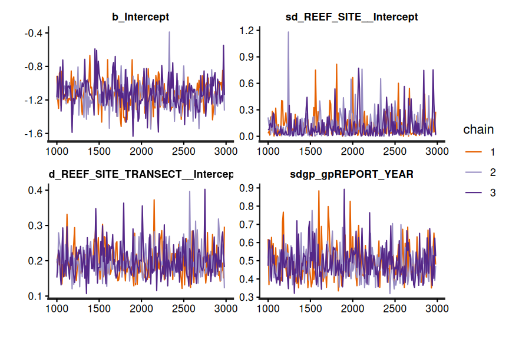

```r
ltmp_sub_brm3$fit |>
    stan_trace(pars = pars)
```

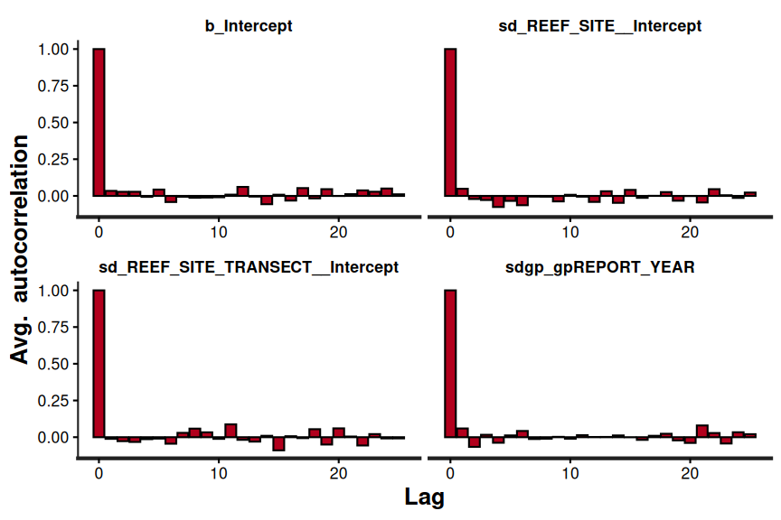

```r
ltmp_sub_brm3$fit |>
    stan_ac(pars = pars)
```

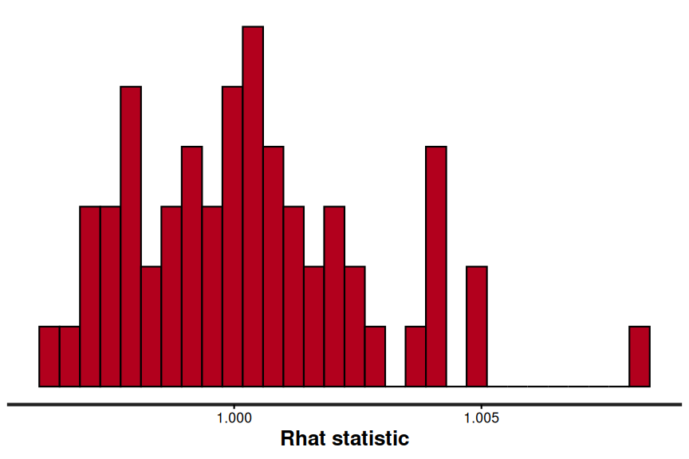

```r
ltmp_sub_brm3$fit |> stan_rhat()
```

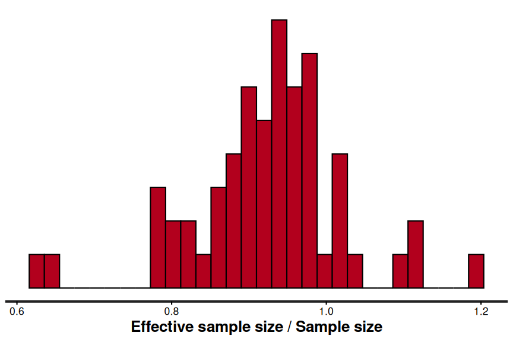

```r
ltmp_sub_brm3$fit |> stan_ess()
```

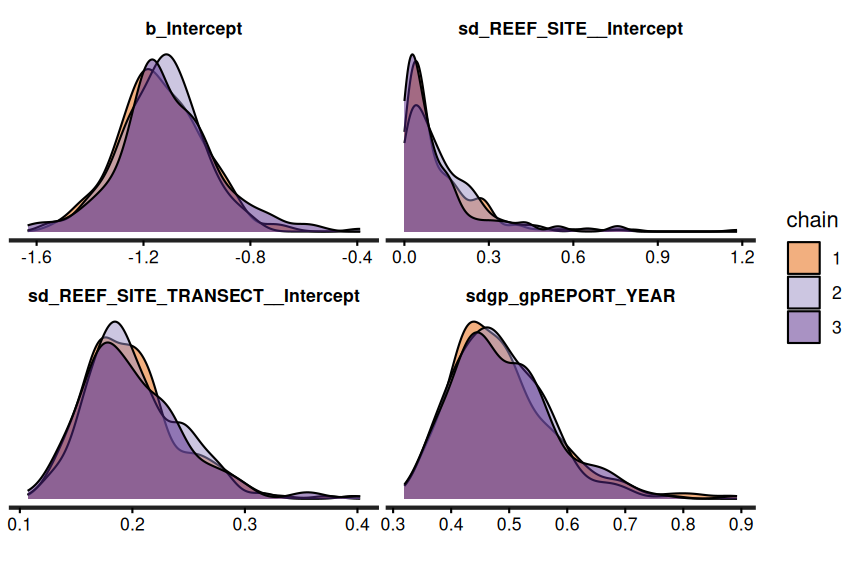

```r
ltmp_sub_brm3$fit |>
    stan_dens(separate_chains = TRUE, pars = pars)
```

**Model validation**

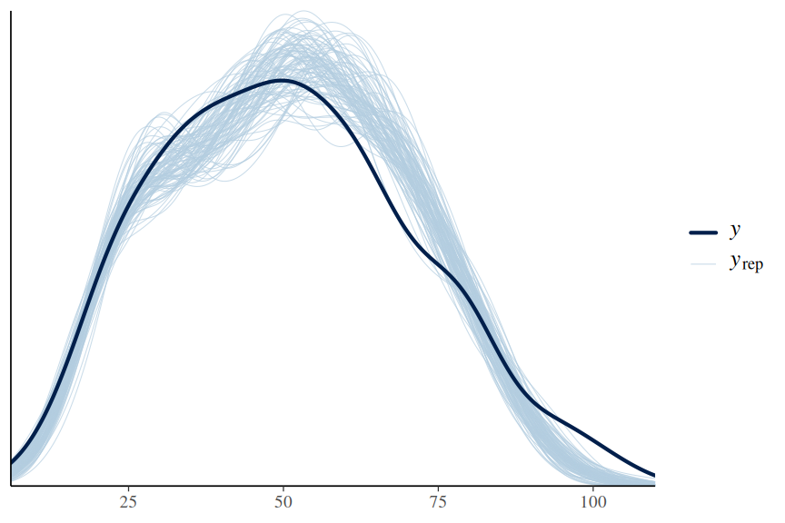

```r
ltmp_sub_brm3 |> pp_check(type = 'dens_overlay', ndraws = 100)
```

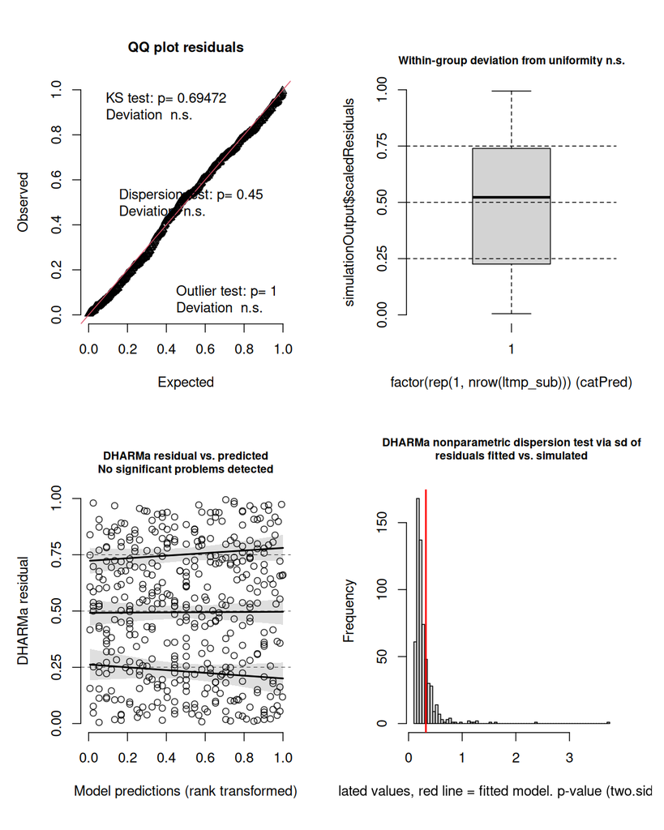

```r
ltmp_sub_resids <- make_brms_dharma_res(ltmp_sub_brm3, integerResponse = TRUE)
wrap_elements(~testUniformity(ltmp_sub_resids)) +
               wrap_elements(~plotResiduals(ltmp_sub_resids, form = factor(rep(1, nrow(ltmp_sub))))) +
               wrap_elements(~plotResiduals(ltmp_sub_resids, quantreg = TRUE)) +
               wrap_elements(~testDispersion(ltmp_sub_resids))
```

**Model investigation**

```r
ltmp_sub_brm3 |> summary()
```

```
 Family: binomial
  Links: mu = logit
Formula: n.points | trials(total.points) ~ gp(REPORT_YEAR) + (1 | REEF_SITE) + (1 | REEF_SITE_TRANSECT)
   Data: ltmp_sub (Number of observations: 418)
  Draws: 3 chains, each with iter = 3000; warmup = 1000; thin = 10;
         total post-warmup draws = 600

Gaussian Process Hyperparameters:
                      Estimate Est.Error l-95% CI u-95% CI Rhat Bulk_ESS
sdgp(gpREPORT_YEAR)       0.49      0.09     0.36     0.69 1.00      535
lscale(gpREPORT_YEAR)     0.04      0.00     0.03     0.04 1.00      570
                      Tail_ESS
sdgp(gpREPORT_YEAR)        553
lscale(gpREPORT_YEAR)      590

Multilevel Hyperparameters:
~REEF_SITE (Number of levels: 3)
              Estimate Est.Error l-95% CI u-95% CI Rhat Bulk_ESS Tail_ESS
sd(Intercept)     0.12      0.14     0.00     0.54 1.01      575      586

~REEF_SITE_TRANSECT (Number of levels: 15)
              Estimate Est.Error l-95% CI u-95% CI Rhat Bulk_ESS Tail_ESS
sd(Intercept)     0.20      0.04     0.13     0.29 1.00      647      570

Regression Coefficients:
          Estimate Est.Error l-95% CI u-95% CI Rhat Bulk_ESS Tail_ESS
Intercept    -1.13      0.16    -1.45    -0.79 1.00      508      372

Draws were sampled using sampling(NUTS). For each parameter, Bulk_ESS
and Tail_ESS are effective sample size measures, and Rhat is the potential
scale reduction factor on split chains (at convergence, Rhat = 1).
```

**Summary figures**

```
Setting all 'trials' variables to 1 by default if not specified otherwise.
```

```
Ignoring unknown labels:
• fill : "NA"
• colour : "NA"
Ignoring unknown labels:
• fill : "NA"
• colour : "NA"
```

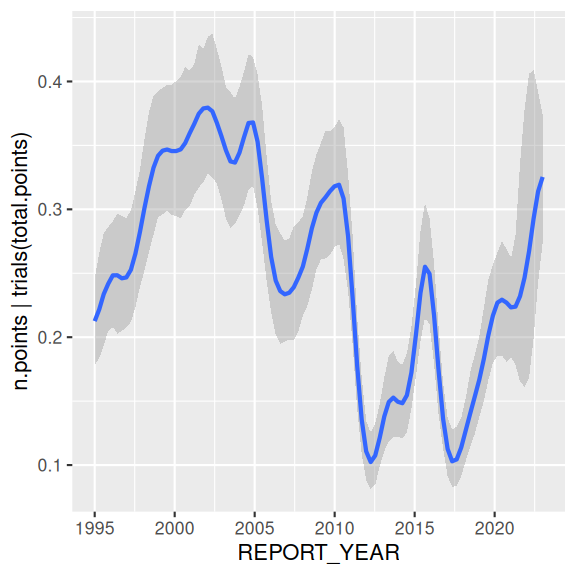

```
Ignoring unknown labels:
• fill : "NA"
• colour : "NA"
```

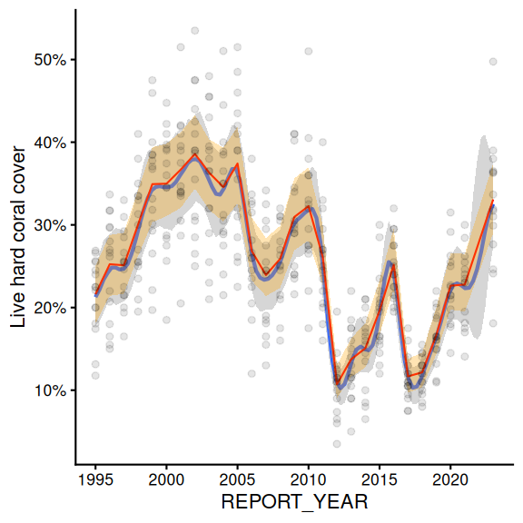

```r
ltmp_glmm <- ltmp_sub_brm1b |>
    emmeans(~fREPORT_YEAR, type = "response") |>
    as.data.frame() |>
    mutate(
        fREPORT_YEAR = factor(fREPORT_YEAR, levels = rev(levels(fREPORT_YEAR))),
        REPORT_YEAR = as.numeric(as.character(fREPORT_YEAR))
    )
ltmp_sub_brm3 |>
  conditional_effects() |>
  plot() |>
  _[[1]] +
  geom_line(data = ltmp_glmm, inherit.aes = FALSE,
    aes(y = prob, x = REPORT_YEAR), colour = "red") +
  geom_ribbon(data = ltmp_glmm, inherit.aes = FALSE,
    aes(y = prob, x = REPORT_YEAR,
      min = lower.HPD, ymax = upper.HPD), fill = "orange", alpha = 0.3) +
  geom_point(data = ltmp_sub,
    aes(y = n.points / total.points, x = REPORT_YEAR), inherit.aes = FALSE, alpha = 0.1) +
  theme_classic() +
  scale_y_continuous("Live hard coral cover", label = scales::percent_format())
```

```
Setting all 'trials' variables to 1 by default if not specified otherwise.
Ignoring unknown labels:
• colour : "NA"Ignoring unknown labels:
• colour : "NA"
```

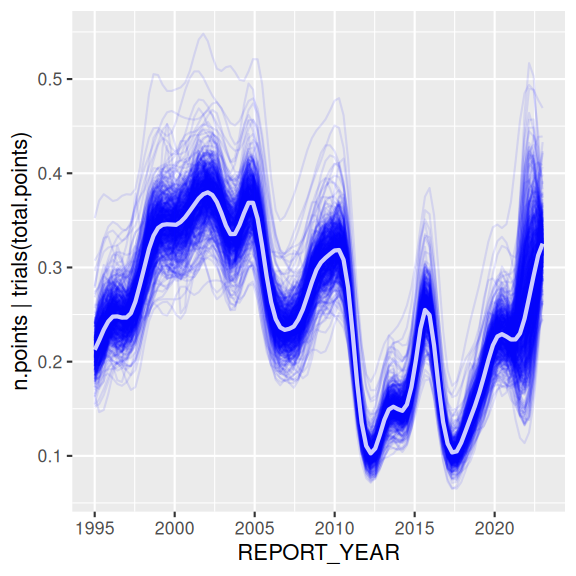

```
Ignoring unknown labels:
• colour : "NA"
```

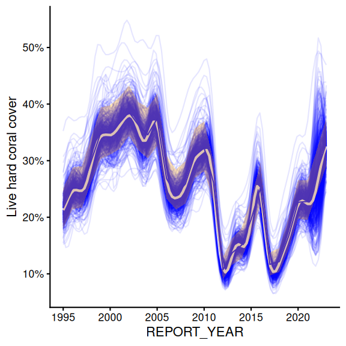

```r
ltmp_sub_brm3 |>
  conditional_effects(spaghetti = TRUE) |>
  plot() |>
  _[[1]] +
  geom_line(data = ltmp_glmm, inherit.aes = FALSE,
    aes(y = prob, x = REPORT_YEAR), colour = "blue") +
  geom_ribbon(data = ltmp_glmm, inherit.aes = FALSE,
    aes(y = prob, x = REPORT_YEAR,
      min = lower.HPD, ymax = upper.HPD), fill = "orange", alpha = 0.3) +
  theme_classic() +
  scale_y_continuous("Live hard coral cover", label = scales::percent_format())
```

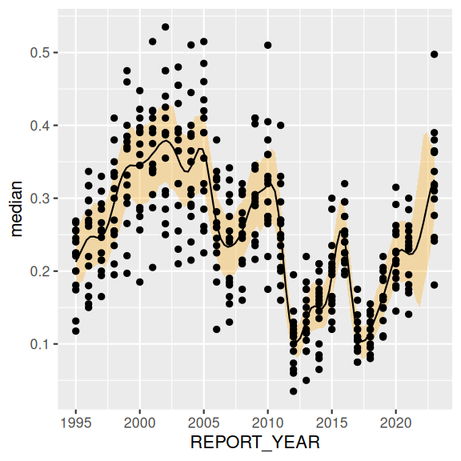

```r
newdata <- data.frame(
  REPORT_YEAR = seq(1995, 2023, len = 100),
  REEF_SITE = NA,
  REEF_SITE_TRANSECT = NA,
  total.points = 1
)
ltmp_sub_sum <-
  ltmp_sub_brm3 |>
    epred_draws(newdata = newdata, re_formula = NA) |>
  ungroup() |>
  dplyr::select(REPORT_YEAR, .epred) |>
  group_by(REPORT_YEAR) |>
  summarise_draws(median, HDInterval::hdi)

ltmp_sub_sum |>
  ggplot(aes(y = median, x = REPORT_YEAR)) +
  geom_ribbon(aes(ymin = lower, ymax = upper), fill = "orange", alpha = 0.3) +
  geom_line() +
  geom_point(data = ltmp_sub,
    aes(y = HC/100))
```

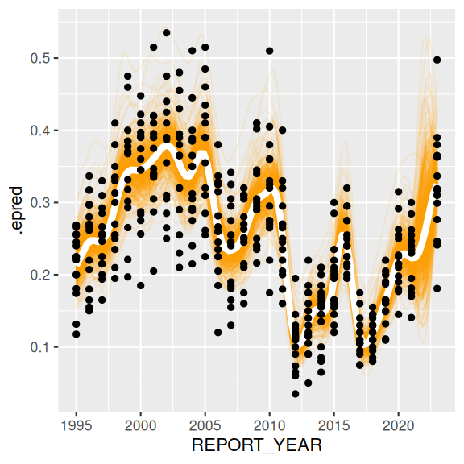

```r
ltmp_gp <- ltmp_sub_sum

ltmp_sub_brm3 |>
  epred_draws(newdata = newdata, re_formula = NA) |>
  ungroup() |>
  dplyr::select(.draw, REPORT_YEAR, .epred) |>
  ggplot(aes(y = .epred, x = REPORT_YEAR)) +
  geom_line(aes(group = .draw), alpha = 0.1, colour = "orange") +
  geom_line(data = ltmp_gp, inherit.aes = FALSE,
    aes(y = median, x = REPORT_YEAR), colour = "white", linewidth = 2) +
  geom_point(data = ltmp_sub,
    aes(y = HC/100, x = REPORT_YEAR))
```

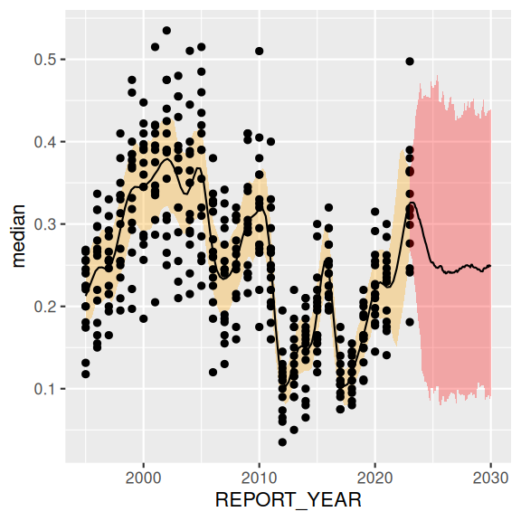

```r
forcast_newdata <- data.frame(
  REPORT_YEAR = seq(2023, 2030, len = 100),
  REEF_SITE = NA,
  REEF_SITE_TRANSECT = NA,
  total.points = 1
)

ltmp_sub_forcast_sum <-
  ltmp_sub_brm3 |>
    epred_draws(newdata = forcast_newdata, re_formula = NA) |>
  ungroup() |>
  dplyr::select(REPORT_YEAR, .epred) |>
  group_by(REPORT_YEAR) |>
  summarise_draws(median, HDInterval::hdi)

ltmp_sub_sum |>
    ggplot(aes(y = median, x = REPORT_YEAR)) +
    geom_ribbon(aes(ymin = lower, ymax = upper), fill = "orange", alpha = 0.3) +
    geom_line() +
    geom_point(
        data = ltmp_sub,
        aes(y = HC / 100)
    ) +
  geom_ribbon(data = ltmp_sub_forcast_sum,
    aes(ymin = lower, ymax = upper), fill = "red", alpha = 0.3) +
  geom_line(data = ltmp_sub_forcast_sum)
```

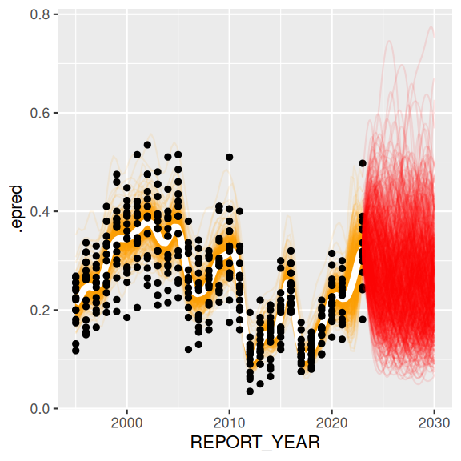

```r
forcast <- ltmp_sub_brm3 |>
    epred_draws(newdata = forcast_newdata, re_formula = NA) |>
    ungroup() |>
  dplyr::select(.draw, REPORT_YEAR, .epred)

ltmp_sub_brm3 |>
    epred_draws(newdata = newdata, re_formula = NA) |>
    ungroup() |>
    dplyr::select(.draw, REPORT_YEAR, .epred) |>
    ggplot(aes(y = .epred, x = REPORT_YEAR)) +
    geom_line(aes(group = .draw), alpha = 0.1, colour = "orange") +
    geom_line(
        data = ltmp_gp, inherit.aes = FALSE,
        aes(y = median, x = REPORT_YEAR), colour = "white", linewidth = 2
    ) +
    geom_point(
        data = ltmp_sub,
        aes(y = HC / 100, x = REPORT_YEAR)
    ) +
  geom_line(data = forcast,
    aes(group = .draw), alpha = 0.1, colour = "red")
```

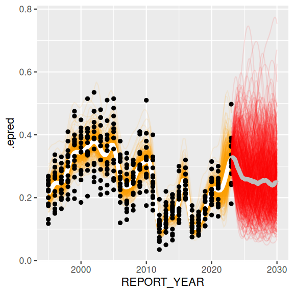

```r
forcast_sum <- forcast |>
  group_by(REPORT_YEAR) |>
  summarise_draws(median, HDInterval::hdi)

ltmp_sub_brm3 |>
    epred_draws(newdata = newdata, re_formula = NA) |>
    ungroup() |>
    dplyr::select(.draw, REPORT_YEAR, .epred) |>
    ggplot(aes(y = .epred, x = REPORT_YEAR)) +
    geom_line(aes(group = .draw), alpha = 0.1, colour = "orange") +
    geom_line(
        data = ltmp_gp, inherit.aes = FALSE,
        aes(y = median, x = REPORT_YEAR), colour = "white", linewidth = 2
    ) +
    geom_point(
        data = ltmp_sub,
        aes(y = HC / 100, x = REPORT_YEAR)
    ) +
  geom_line(data = forcast,
    aes(group = .draw), alpha = 0.1, colour = "red") +
  geom_line(
    data = forcast_sum, inherit.aes = FALSE,
    aes(y = median, x = REPORT_YEAR), colour = "grey", linewidth = 2
  )
```

```r
newdata <- data.frame(
  REPORT_YEAR = c(1995, 2005),
  REEF_SITE = NA,
  REEF_SITE_TRANSECT = NA,
  total.points = 1
)
ltmp_sub_sum <-
  ltmp_sub_brm3 |>
  epred_draws(newdata = newdata, re_formula = NA) |>
  tidybayes::compare_levels(
    var = .epred, by = REPORT_YEAR,
    comparison = emmeans_comparison("revpairwise")
  ) |>
  ungroup() |>
  dplyr::select(REPORT_YEAR, .epred) |>
  group_by(REPORT_YEAR) |>
  summarise_draws(median, HDInterval::hdi)


  ltmp_sub_brm3 |>
  epred_draws(newdata = newdata, re_formula = NA) |>
  mutate(.epred = log(.epred)) |>
  tidybayes::compare_levels(
    var = .epred, by = REPORT_YEAR,
    comparison = emmeans_comparison("revpairwise")
  ) |>
  ungroup() |>
  dplyr::select(REPORT_YEAR, .epred) |>
  mutate(.epred = exp(.epred)) |>
  group_by(REPORT_YEAR) |>
  summarise_draws(median, HDInterval::hdi)
```

```
# A tibble: 1 × 5
# Groups:   REPORT_YEAR [1]
  REPORT_YEAR variable median lower upper
  <chr>       <chr>     <dbl> <dbl> <dbl>
1 2005 - 1995 .epred     1.72  1.55  1.88
```